# 20 Generalized linear model

Tobias Gerstenberg

2/26/2020

> Thank you for providing interpretations on the graphs as well as the issues that were problematic with them. It was a bit difficult to make jump into log odds without doing the math ourselves, but the slides lay it out well. I would still incorporate more time to talk to a neighbor for example when interpreting log odds.

> The classes on linear mixed effects and this class were great! I was able to understand things that I hadn’t understood before. I particularly appreciated the material on how to interpret the coefficients of logistic regression! Thanks for these great classes, Tobi!

> I’d like to hear more explanations about how the concepts we learn are related to each other. For example, how is partial pooling related to linear mixed effects model?

> One thing in general that I feel like I still don’t have a good sense of us how to model likert style data. I don’t really have an idea of what a good strategy would be.

> I really appreciate learning about the mixed models and multilevel modeling, it is super helpful for research! **One thing that could be helpful in improving is giving a high-level definition of new concepts before jumping into the stats breakdown**. For example, “we use a logit transform to do X” before all of the complicated formulas appear, I got really lost there. (And also with concepts like AIC/BIC)

> Clear explanations on logistic regression. **Moving forward I really hope to know how we can address non-normality of residuals in our linear models.**

> I’m honestly a bit lost…

## Student feedback

|  | response |
| --- | --- |
| 1 | not about class, but the way that you have been announcing dates for things is not ideal. You said the homework would be released on saturday night. When I look at the Canvas folders for the homework … |
| 2 | Thank you for providing interpretations on the graphs as well as the issues that were problematic with them. It was a bit difficult to make jump into log odds without doing the math ourselves, but the… |
| 3 | I would have liked to go through the math transformations a bit more slowly. The part where you transform from a y, to a probability, to odds, to log of odds. I didn't fully understand every step ther… |
| 4 | The classes on linear mixed effects and this class were great! I was able to understand things that I hadn't understood before. I particularly appreciated the material on how to interpret the coeffici… |
| 5 | I'd like to hear more explanations about how the concepts we learn are related to each other. For example, how is partial pooling related to linear mixed effects model? |
| 6 | One thing in general that I feel like I still don't have a good sense of us how to model likert style data. I don't really have an idea of what a good strategy would be. |
| 7 | I really appreciate learning about the mixed models and multilevel modeling, it is super helpful for research! One thing that could be helpful in improving is giving a high-level definition of new con… |
| 8 | Oye. I'm lost. I still don't understand how to interpret these outputs very well. |
| 9 | I enjoyed this and the prior classes on mixed effects models. These are two concepts/tests that I'm using in my research and have had trouble with, so I was looking forward to these two topics. It was… |
| 10 | I like the application of the models, it gives me more confidence when using them in my data. |

[output cut: 9 more lines]

### PollEverywhere results

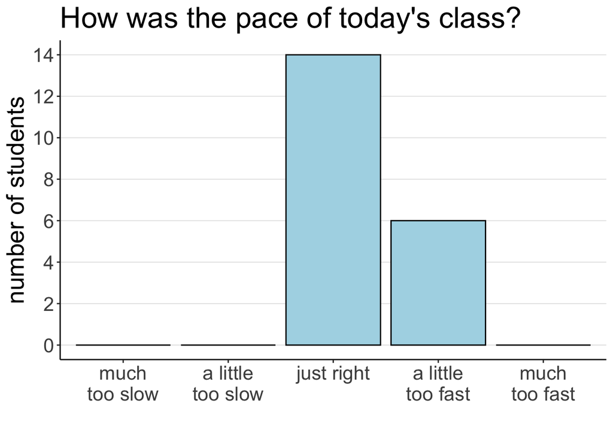

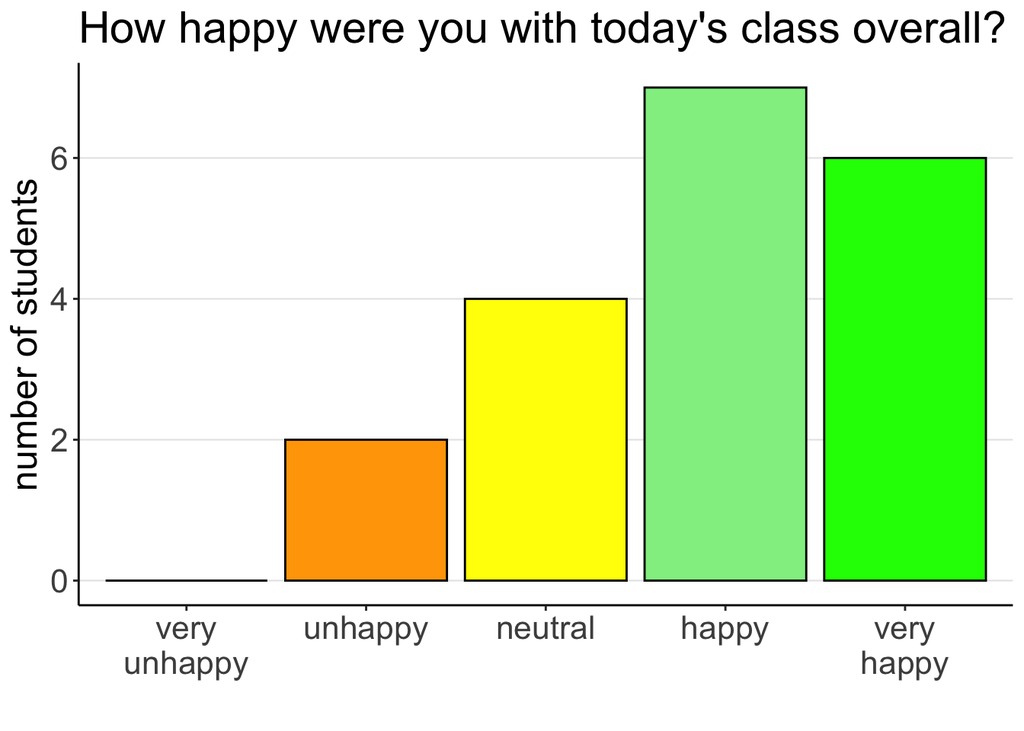

## What to do next time

- try and have more interactivity in class again (e.g. talk to your neighbor exercises)
- go slower through the parts about the transformation to log odds
- try to give high-level definitions of new concepts before then going into more detail in explaining them